# APM1205 Formative Assessment 2: Simple Linear Least-Squares Regression

Data Analysis Report

2026-09-13

# Simple Linear Least-Squares Regression

## 1. Scatterplot and Regression Line

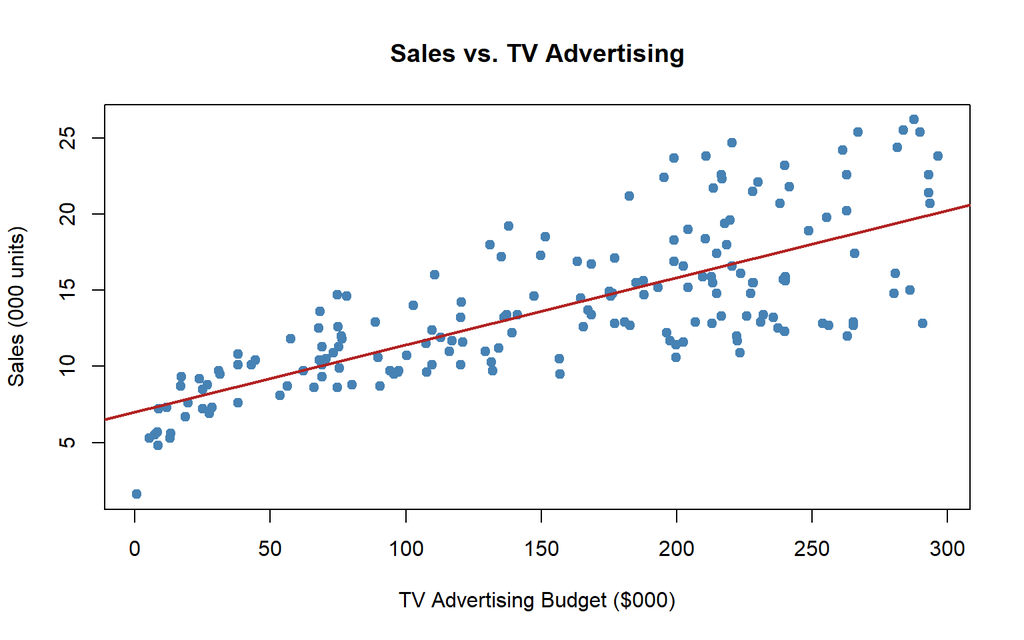

```r
plot(
  adv_data$TV,
  adv_data$Sales,
  main = "Sales vs. TV Advertising",
  xlab = "TV Advertising Budget ($000)",
  ylab = "Sales (000 units)",
  pch = 19,
  col = "steelblue"
)

abline(
  lm(Sales ~ TV, data = adv_data),
  col = "firebrick",
  lwd = 2
)
```

The scatterplot shows the relationship between TV advertising expenditure and sales. The fitted regression line provides a visual representation of the linear relationship between the two variables.

## 2. Simple Linear Regression Model

The simple linear regression model is fitted with Sales as the dependent variable and TV advertising as the explanatory variable.

```r
model <- lm(Sales ~ TV, data = adv_data)

summary(model)
```

```
##
## Call:
## lm(formula = Sales ~ TV, data = adv_data)
##
## Residuals:
##     Min      1Q  Median      3Q     Max
## -7.0367 -1.9861 -0.2278  2.0094  7.9726
##
## Coefficients:
##             Estimate Std. Error t value Pr(>|t|)
## (Intercept) 6.997796   0.515211   13.58   <2e-16 ***
## TV          0.044165   0.002833   15.59   <2e-16 ***
## ---
## Signif. codes:  0 '***' 0.001 '**' 0.01 '*' 0.05 '.' 0.1 ' ' 1
##
## Residual standard error: 3.339 on 198 degrees of freedom
## Multiple R-squared:  0.551,  Adjusted R-squared:  0.5487
## F-statistic:   243 on 1 and 198 DF,  p-value: < 2.2e-16
```

The regression equation can be obtained from the estimated coefficients:

```r
intercept <- coef(model)[1]
slope <- coef(model)[2]

cat(
  "Estimated Regression Equation:\n",
  "Sales =", round(intercept, 4),
  "+", round(slope, 4), "* TV"
)
```

```
## Estimated Regression Equation:
##  Sales = 6.9978 + 0.0442 * TV
```

The slope represents the expected change in sales for every one-unit increase in TV advertising expenditure.

## 3. Predicted Sales and Residuals

```r
adv_data$Predicted_Sales <- fitted(model)
adv_data$Residual <- residuals(model)

kable(
  head(
    adv_data[, c("TV", "Sales", "Predicted_Sales", "Residual")],
    10
  ),
  digits = 4,
  caption = "First 10 Observations: Actual vs. Fitted Values and Residuals"
)
```

First 10 Observations: Actual vs. Fitted Values and Residuals

| TV | Sales | Predicted_Sales | Residual |
| --- | --- | --- | --- |
| 230.1 | 22.1 | 17.1602 | 4.9398 |
| 44.5 | 10.4 | 8.9632 | 1.4368 |
| 17.2 | 9.3 | 7.7574 | 1.5426 |
| 151.5 | 18.5 | 13.6888 | 4.8112 |
| 180.8 | 12.9 | 14.9829 | -2.0829 |
| 8.7 | 7.2 | 7.3820 | -0.1820 |
| 57.5 | 11.8 | 9.5373 | 2.2627 |
| 120.2 | 13.2 | 12.3065 | 0.8935 |
| 8.6 | 4.8 | 7.3776 | -2.5776 |
| 199.8 | 10.6 | 15.8220 | -5.2220 |

The predicted sales values are obtained from the fitted regression model. The residual for each observation is calculated as:

$$e_i = y_i - \hat{y}_i$$

where $y_i$ is the observed sales value and $\hat{y}_i$ is the predicted sales value.

## 4. Residuals vs. Fitted Values

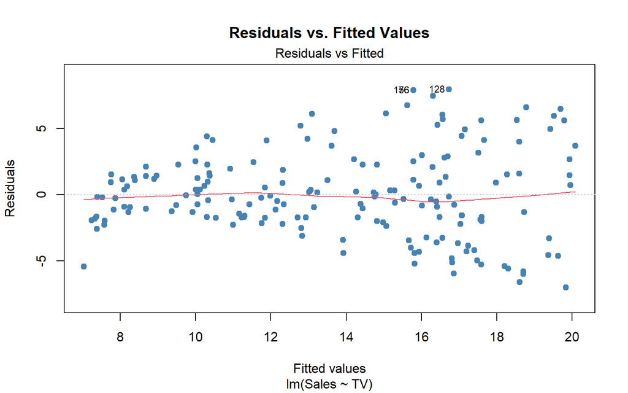

```r
plot(
  model,
  which = 1,
  main = "Residuals vs. Fitted Values",
  col = "steelblue",
  pch = 19
)
```

The residual plot can be used to assess whether a linear regression model is appropriate. Ideally, the residuals should be randomly scattered around zero without a clear systematic pattern.

## 5. Residual Standard Error

```r
rse_val <- summary(model)$sigma

cat(
  "Residual Standard Error (Se):",
  round(rse_val, 4)
)
```

```
## Residual Standard Error (Se): 3.3387
```

The residual standard error measures the typical size of the prediction errors made by the regression model. A smaller value indicates that the observed values tend to be closer to the fitted regression line.

## 6. Decomposition of Sums of Squares

```r
y <- adv_data$Sales
yhat <- fitted(model)

TSS <- sum((y - mean(y))^2)
RSS <- sum((y - yhat)^2)
RegSS <- TSS - RSS

ss_table <- data.frame(
  Measure = c(
    "Total Sum of Squares (TSS)",
    "Residual Sum of Squares (RSS)",
    "Regression Sum of Squares (RegSS)",
    "Verified Sum (RegSS + RSS)"
  ),
  Value = c(
    TSS,
    RSS,
    RegSS,
    RegSS + RSS
  )
)

kable(
  ss_table,
  digits = 4,
  caption = "Decomposition of Sums of Squares"
)
```

Decomposition of Sums of Squares

| Measure | Value |
| --- | --- |
| Total Sum of Squares (TSS) | 4915.421 |
| Residual Sum of Squares (RSS) | 2207.050 |
| Regression Sum of Squares (RegSS) | 2708.371 |
| Verified Sum (RegSS + RSS) | 4915.421 |

The total variation in sales is divided into the variation explained by the regression model and the unexplained residual variation:

$$TSS = RegSS + RSS$$

The calculated values provide a verification of this relationship.

## 7. Correlation Coefficient and Coefficient of Determination

```r
r <- cor(adv_data$TV, adv_data$Sales)
r_squared <- summary(model)$r.squared

cat(
  "Correlation Coefficient (r):",
  round(r, 4),
  "\n"
)
```

```
## Correlation Coefficient (r): 0.7423
```

```r
cat(
  "Coefficient of Determination (r²):",
  round(r_squared, 4)
)
```

```
## Coefficient of Determination (r²): 0.551
```

The correlation coefficient measures the strength and direction of the linear relationship between TV advertising expenditure and sales.

The coefficient of determination, $R^2$, represents the proportion of variation in sales that is explained by TV advertising through the fitted linear regression model.

## 8. Regression Statistics

```r
model_summary <- summary(model)

statistics_table <- data.frame(
  Statistic = c(
    "Correlation Coefficient (r)",
    "R-squared (R²)",
    "Adjusted R-squared",
    "Residual Standard Error",
    "Number of Observations"
  ),
  Value = c(
    r,
    model_summary$r.squared,
    model_summary$adj.r.squared,
    model_summary$sigma,
    nrow(adv_data)
  )
)

kable(
  statistics_table,
  digits = 4,
  caption = "Summary of Regression Statistics"
)
```

Summary of Regression Statistics

| Statistic | Value |
| --- | --- |
| Correlation Coefficient (r) | 0.7423 |
| R-squared (R²) | 0.5510 |
| Adjusted R-squared | 0.5487 |
| Residual Standard Error | 3.3387 |
| Number of Observations | 200.0000 |

## 9. Conclusion

```r
cat(
  "The simple linear regression analysis examines the relationship between TV advertising expenditure and sales. ",
  "The fitted regression model quantifies the relationship between these two variables. ",
  "The correlation coefficient indicates the direction and strength of the linear association, ",
  "while the coefficient of determination (R²) indicates the proportion of variation in sales explained by TV advertising. ",
  "The residual analysis provides a diagnostic assessment of the suitability of the linear regression model."
)
```

The simple linear regression analysis examines the relationship between TV advertising expenditure and sales. The fitted regression model quantifies the relationship between these two variables. The correlation coefficient indicates the direction and strength of the linear association, while the coefficient of determination (R²) indicates the proportion of variation in sales explained by TV advertising. The residual analysis provides a diagnostic assessment of the suitability of the linear regression model.